# Barplots and phylogenetic trees

J. Ignacio Lucas Lledó

28/4/2020

```r
knitr::opts_chunk$set(echo = TRUE)
library(phyloseq)
library(ggplot2)
library(ape)
library(ggtree)
library(tidytree)
load('../2020-02-27/ps.RData')
load('../2020-04-22/Diversity.RData')
# These are amplicons significantly associated with low or high
# levels of PC1 and PC3 of life-history traits. See 2020-05-01
PC1low <- c('A0108','A0121','A0128','A0126','A0131','A0140',
            'A0150','A0152','A0144','A0166','A0171')
PC3low <- c('A0207','A0229','A0252','A0254','A0257','A0269',
            'A0264','A0261','A0260','A0281','A0282','A0128')
PC3high <- 'A0076'
```

# Barplot of abundances

The reason I have not produced a barplot of abundances before is twofold. First, I didn’t like the output of the `plot_bar()` function in the phyloseq package: it doesn’t make it easy at all to remove the black border around the boxes. And second, the large number of amplicons and the low diversity of the compositions make barplots not very informative, unless carefully customized.

I tried again the `plot_bar()` function in `phyloseq`, following this [tutorial](https://joey711.github.io/phyloseq/plot_bar-examples.html). However, I find it necessary to *melt* the dataset and work directly with `ggplot2`, to remove the default borders around each amplicon’s abundance.

In all barplots below, I stack relative abundances from the same isoline and age. That makes the height of the bar equal to the number of replicates for each isoline and age, which is either 3 or 4. In order to represent compositions relative to the same reference level, I divide samples’ relative abundances by the number of samples from the same isoline and age. Thus, the height of the bars represent average values among replicates of the same isoline and age.

```r
NumRep <- table(sample_data(ps)[,c('age', 'isoline')])
NumRep
```

```
##        isoline
## age     6 10 11 12 14 15 17 19 20 22 23 24 25 26 27 28 29 30 31 33 35 36 38 39
##   Early 3  3  3  3  3  3  4  4  3  4  4  3  4  4  3  4  4  4  4  4  4  4  4  4
##   Late  4  4  4  4  4  3  4  4  3  4  3  3  4  4  3  4  4  4  4  4  3  4  4  4
```

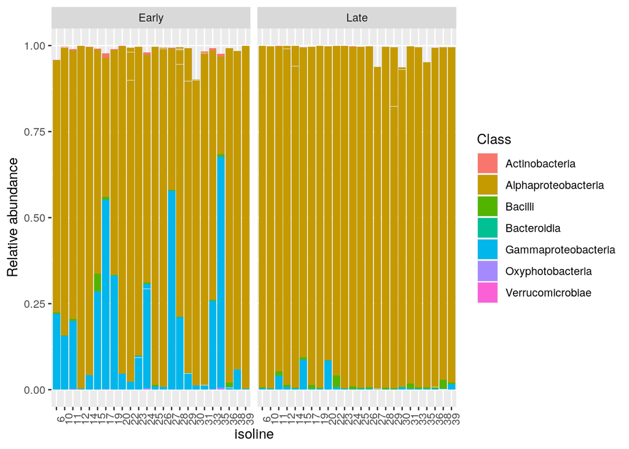

```r
ps.prop.melted <- psmelt(ps.prop)
ps.prop.melted$IsoAbundance <- numeric(length = length(ps.prop.melted$Abundance))
isEarly <- ps.prop.melted$age == 'Early'
isLate  <- ps.prop.melted$age == 'Late'
ps.prop.melted[isEarly, 'IsoAbundance'] <- ps.prop.melted[isEarly, 'Abundance'] /
  NumRep['Early', ps.prop.melted[isEarly, 'isoline']]
ps.prop.melted[isLate, 'IsoAbundance'] <- ps.prop.melted[isLate, 'Abundance'] /
  NumRep['Late', ps.prop.melted[isLate, 'isoline']]
rm(isEarly, isLate)
ggplot(ps.prop.melted, aes(x = isoline, y = IsoAbundance, fill = Class)) +
  geom_bar(stat = 'identity', position = 'stack') +
  facet_wrap(~ age) +
  theme(axis.text.x = element_text(angle = 90)) +
  ylab('Relative abundance')
```

```r
ggsave(filename = 'Barplot_Isoline_Abundance_Class.png')
```

I found the Class taxonomic level to be the easiest to visualize in the barplot above. There are 7 Classes and 6 Phyla. The correspondence is the following:

```
## Taxonomy Table:     [7 taxa by 2 taxonomic ranks]:
##       Phylum            Class
## A0001 "Proteobacteria"  "Alphaproteobacteria"
## A0143 "Proteobacteria"  "Gammaproteobacteria"
## A0563 "Firmicutes"      "Bacilli"
## A0830 "Verrucomicrobia" "Verrucomicrobiae"
## A0868 "Actinobacteria"  "Actinobacteria"
## A0877 "Cyanobacteria"   "Oxyphotobacteria"
## A1907 "Bacteroidetes"   "Bacteroidia"
```

In the barplot above, some bars do not reach the maximum height of 1. The reason is that low-abundance amplicons, filtered out in a previous step made up the missing fraction.

Below, I break down the average relative abundances by Class.

```r
z <- split(ps.prop.melted, ps.prop.melted$Class)
names(z)
```

```
## [1] "Actinobacteria"      "Alphaproteobacteria" "Bacilli"
## [4] "Bacteroidia"         "Gammaproteobacteria" "Oxyphotobacteria"
## [7] "Verrucomicrobiae"
```

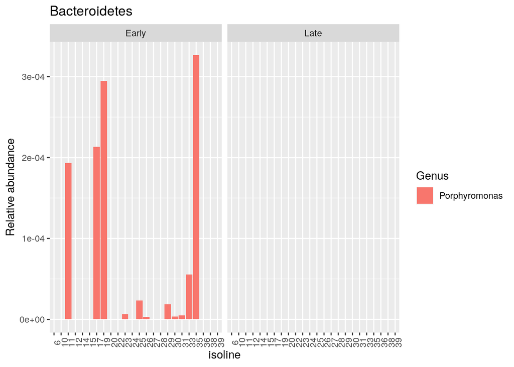

```r
p <- list(length=length(z))
for (i in 1:length(z)) {
  z[[i]]$Genus <- droplevels(z[[i]]$Genus)
}
ggplot(z$Bacteroidia, aes(x=isoline, y=IsoAbundance, fill=Genus)) +
  geom_bar(stat='identity', position='stack') +
  facet_wrap(~ age) +
  theme(axis.text.x=element_text(angle=90)) +
  ylab('Relative abundance') + ggtitle('Bacteroidetes')
```

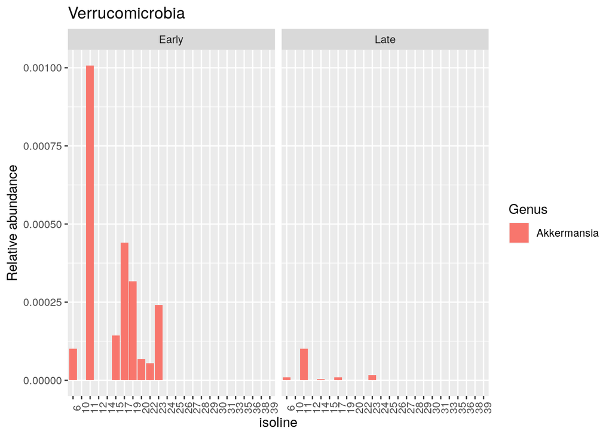

```r
ggsave(filename = 'Barplot_Isoline_Abundance_Bacteroidetes.png')
ggplot(z$Verrucomicrobiae, aes(x=isoline, y=IsoAbundance, fill=Genus)) +
  geom_bar(stat='identity', position='stack') +
  facet_wrap(~ age) +
  theme(axis.text.x=element_text(angle=90)) +
  ylab('Relative abundance') + ggtitle('Verrucomicrobia')
```

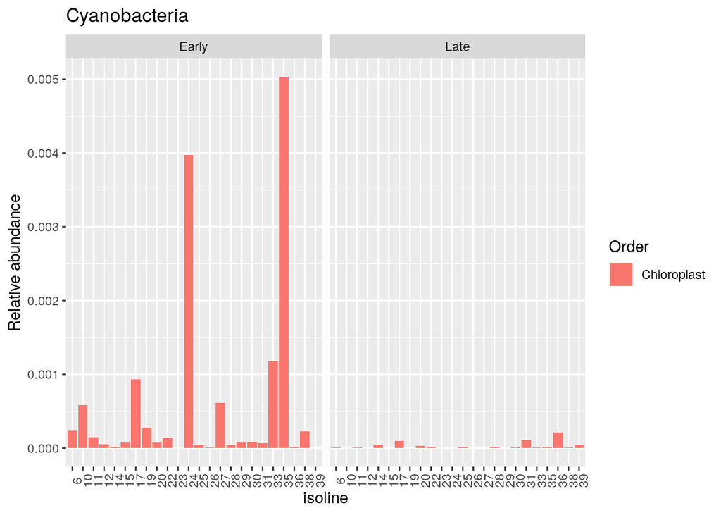

```r
ggsave(filename = 'Barplot_Isoline_Abundance_Verrucomicrobia.png')
ggplot(z$Oxyphotobacteria, aes(x=isoline, y=IsoAbundance, fill=Order)) +
  geom_bar(stat='identity', position='stack') +
  facet_wrap(~ age) +
  theme(axis.text.x=element_text(angle=90)) +
  ylab('Relative abundance') + ggtitle('Cyanobacteria')
```

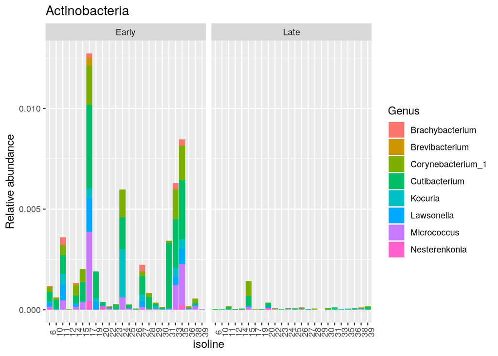

```r
ggsave(filename = 'Barplot_Isoline_Abundance_Cyanobacteria.png')
ggplot(z$Actinobacteria, aes(x=isoline, y=IsoAbundance, fill=Genus)) +
  geom_bar(stat='identity', position='stack') +
  facet_wrap(~ age) +
  theme(axis.text.x=element_text(angle=90)) +
  ylab('Relative abundance') + ggtitle('Actinobacteria')
```

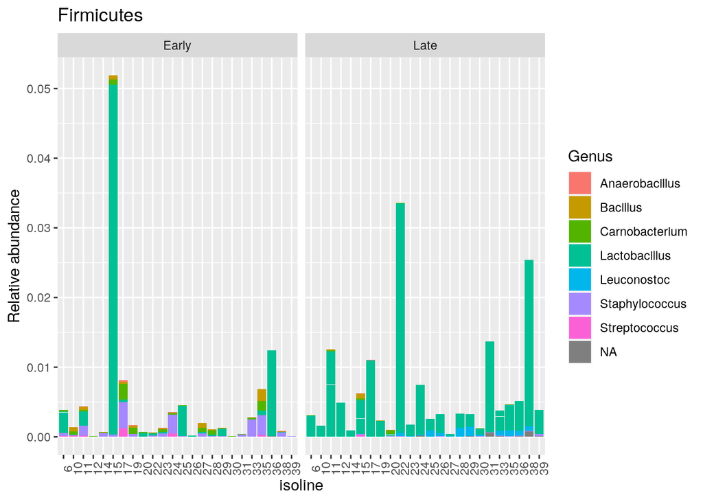

```r
ggsave(filename = 'Barplot_Isoline_Abundance_Actinobacteria.png')
ggplot(z$Bacilli, aes(x=isoline, y=IsoAbundance, fill=Genus)) +
  geom_bar(stat='identity', position='stack') +
  facet_wrap(~ age) +
  theme(axis.text.x=element_text(angle=90)) +
  ylab('Relative abundance') + ggtitle('Firmicutes')
```

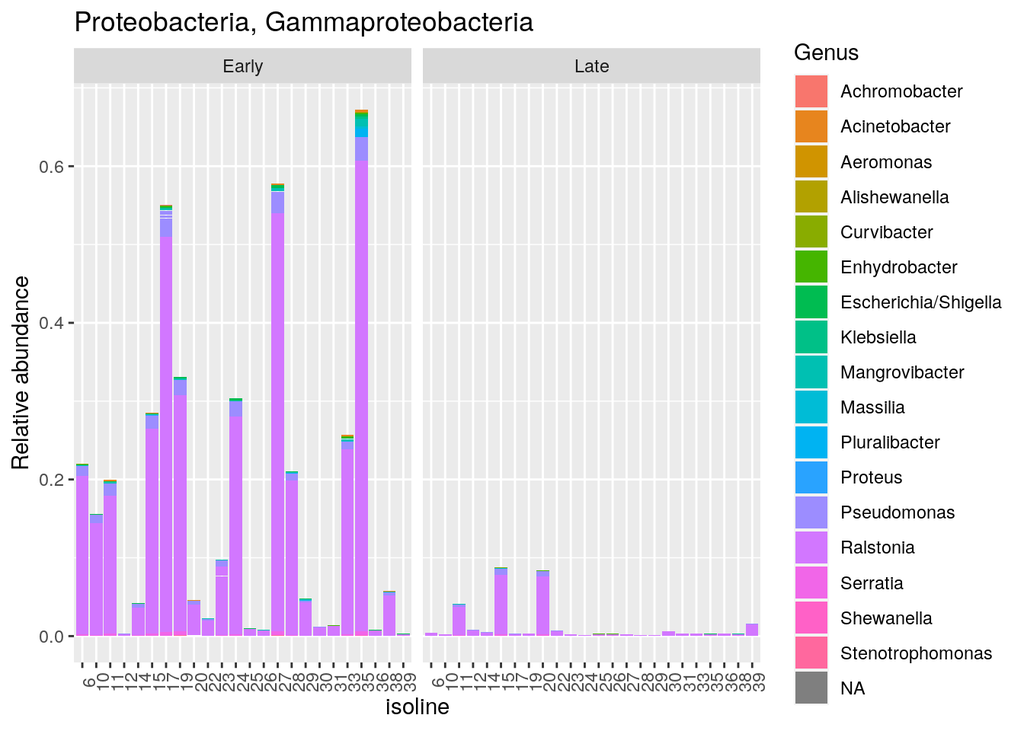

```r
ggsave(filename = 'Barplot_Isoline_Abundance_Firmicutes.png')
ggplot(z$Gammaproteobacteria, aes(x=isoline, y=IsoAbundance, fill=Genus)) +
  geom_bar(stat='identity', position='stack') +
  facet_wrap(~ age) +
  theme(axis.text.x=element_text(angle=90)) +
  ylab('Relative abundance') + ggtitle('Proteobacteria, Gammaproteobacteria')
```

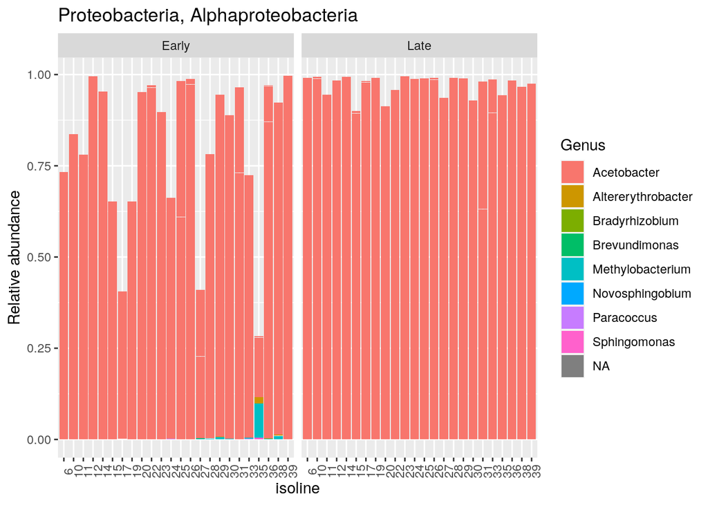

```r
ggsave(filename = 'Barplot_Isoline_Abundance_Gammaproteobacteria.png')
ggplot(z$Alphaproteobacteria, aes(x=isoline, y=IsoAbundance, fill=Genus)) +
  geom_bar(stat='identity', position='stack') +
  facet_wrap(~ age) +
  theme(axis.text.x=element_text(angle=90)) +
  ylab('Relative abundance') + ggtitle('Proteobacteria, Alphaproteobacteria')
```

```r
ggsave(filename = 'Barplot_Isoline_Abundance_Alphaproteobacteria.png')
```

In the plots above we can see clear patters. Remarkably, the disappearance of almost anything that is not *Acetobacter*, except for *Lactobacillus*. The reduction of within-isoline diversity (Alpha diversity?) was known before. Now it is also clear that Beta diversity also goes down: it is **not** the case that isolines differentiate with age. Rather, they converge to a similar state, as in an ecological succession.

# Phylogenetic trees

The analysis with Lefse (Segata et al. 2011) (`2020-05-01`) identified a few amplicons significantly associated with low (only one with high) loadings of isolines on principal components of life-history traits. All of those amplicons belong to *Acetobacter*, which is not surprising, for it is the most abundant genus. If amplicons aparently associated with life-history traits were clustered within the *Acetobacter* phylogeny, the possibility that they are actually rellevant for the fly’s physiology would be more plausible.

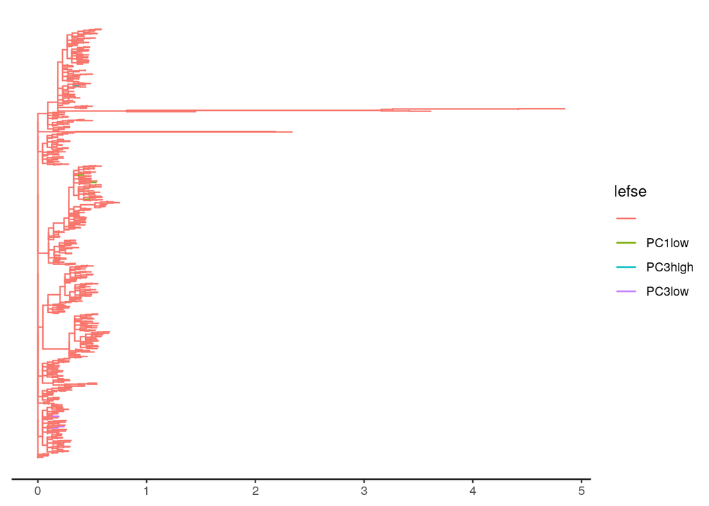

```r
# The amplicons in the tree are these (ordered):
AmpFilt <- sort(colnames(EA)[EA.filter | LA.filter])
stopifnot(all.equal(AmpFilt, names(fitGTR$data)))
TreeTraits <- Traits[AmpFilt,]
TreeTraits$label <- rownames(TreeTraits)
TreeAceto <- drop.tip(fitGTR$tree, TreeTraits[! TreeTraits$Genus %in% 'Acetobacter', 'label'])
TibbAceto <- as_tibble(TreeAceto)
TibbAceto$lefse <- character(length=dim(TibbAceto)[1])
TibbAceto[TibbAceto$label %in% PC1low, 'lefse'] <- 'PC1low'
TibbAceto[TibbAceto$label %in% PC3low, 'lefse'] <- 'PC3low'
TibbAceto[TibbAceto$label %in% PC3high, 'lefse'] <- 'PC3high'
TDAceto <- as.treedata(TibbAceto)
ggtree(TDAceto, aes(color=lefse)) + theme_tree2()
```

I need to remove the long branches. And the colors on leaves don’t help. I also discard the least significant amplicon from the `PC3low` set, which belongs to a different clade, and messes up the plot.

```r
TibbAceto[TibbAceto$branch.length > 0.4,]
```

```
## # A tibble: 8 x 5
##   parent  node branch.length label lefse
##    <int> <int>         <dbl> <chr> <chr>
## 1   1251   752         1.99  A1543 ""
## 2   1245   804         0.634 A1910 ""
## 3   1250   821         0.427 A2130 ""
## 4   1251   825         1.84  A2172 ""
## 5     NA    NA        NA     <NA>   <NA>
## 6   1084  1245         0.633 <NA>  ""
## 7   1245  1246         2.34  <NA>  ""
## 8   1249  1250         1.15  <NA>  ""
```

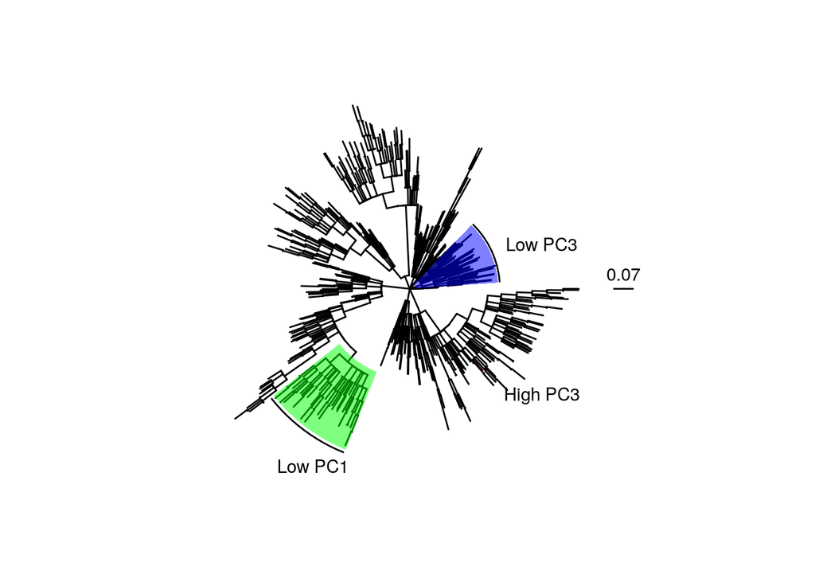

```r
# Manually identified these tips in long branches:
TDAcetoShort <- treeio::drop.tip(TDAceto, c('A1543', 'A1910', 'A2130', 'A2172',
                                      'A1818', 'A1067', 'A1306', 'A1787', 'A1962'))
ggtree(TDAcetoShort, layout = 'circular') +
  geom_hilight(node = MRCA(TDAcetoShort, PC1low), fill='green', alpha=0.5) +
  geom_hilight(node = MRCA(TDAcetoShort, PC3low[-12]), fill='blue', alpha=0.5) +
  geom_hilight(node = MRCA(TDAcetoShort, PC3high), fill='red', alpha=0.5) +
  geom_cladelabel(node = MRCA(TDAcetoShort, PC1low), label='Low PC1', offset.text=0.15) +
  geom_cladelabel(node = MRCA(TDAcetoShort, PC3low[-12]), label='Low PC3', offset.text=0.05) +
  geom_cladelabel(node = MRCA(TDAcetoShort, PC3high), label='High PC3', offset.text=0.1) +
  geom_treescale(x=0.7, offset=5)
```

```r
ggsave(filename = 'Acetobacter_Circular_Lefse_highlight.png')
```

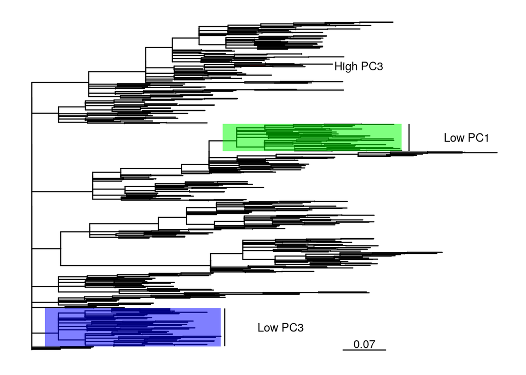

```r
ggtree(TDAcetoShort, layout = 'rectangular') +
  geom_hilight(node = MRCA(TDAcetoShort, PC1low), fill='green', alpha=0.5) +
  geom_hilight(node = MRCA(TDAcetoShort, PC3low[-12]), fill='blue', alpha=0.5) +
  geom_hilight(node = MRCA(TDAcetoShort, PC3high), fill='red', alpha=0.5) +
  geom_cladelabel(node = MRCA(TDAcetoShort, PC1low), label='Low PC1', offset.text=0.05) +
  geom_cladelabel(node = MRCA(TDAcetoShort, PC3low[-12]), label='Low PC3', offset.text=0.05) +
  geom_cladelabel(node = MRCA(TDAcetoShort, PC3high), label='High PC3', offset.text=0.1) +
  geom_treescale(x=0.5, offset=5)
```

```r
ggsave(filename = 'Acetobacter_Rectangular_Lefse_highlight.png')
```

After removing just one amplicon (the least significant one) from the set of amplicons identified by Lefse as associated with low fitness loadings on PC3, it becomes clear that significant amplicons are phylogenetically clustered. Amplicons with the same presumed effect on fitness components are closely related within the genus tree. In principle, this looks like a strong support for the biological significance of the finding. It also suggests that had the amplicons been grouped appropriately, the signal would have been stronger.

In the figure, not all highlighted amplicons are significant. The highlighted clades are defined by the most recent common ancestor of significant amplicons with the same presumed effect.

```r
save(TDAceto, TDAcetoShort, file='figures.RData')
```

# References

McMurdie, Paul J., and Susan Holmes. 2013. “Phyloseq: An R Package for Reproducible Interactive Analysis and Graphics of Microbiome Census Data.” *PLoS ONE* 8 (4): e61217. http://dx.plos.org/10.1371/journal.pone.0061217.

Paradis, E., and K. Schliep. 2018. “Ape 5.0: An Environment for Modern Phylogenetics and Evolutionary Analyses in R.” *Bioinformatics* 35: 526–28.

Segata, N., J. Izard, L. Waldron, D. Gevers, L. Miropolsky, W.S. Garrett, and C. Huttenhower. 2011. “Metagenomic Biomarker Discovery and Explanation.” *Genome Biology* 12: R60. doi:10.1186/gb-2011-12-6-r60.

Wickham, Hadley. 2016. *Ggplot2: Elegant Graphics for Data Analysis*. Springer-Verlag New York. https://ggplot2.tidyverse.org.

Yu, Guangchuang. 2020. *Tidytree: A Tidy Tool for Phylogenetic Tree Data Manipulation*. https://CRAN.R-project.org/package=tidytree.

Yu, Guangchuang, David Smith, Huachen Zhu, Yi Guan, and Tommy Tsan-Yuk Lam. 2017. “Ggtree: An R Package for Visualization and Annotation of Phylogenetic Trees with Their Covariates and Other Associated Data.” *Methods in Ecology and Evolution* 8 (1): 28–36. doi:10.1111/2041-210X.12628.